# USGS Stream Discharge Analysis

## 4. Data Cleaning

This chunk does four things:

1. **Selects** only `Date` and `Flow` — all other NWIS metadata columns are dropped.
2. **Removes** rows where `Flow` is `NA` (equipment malfunctions and provisional data gaps appear as `NA`).
3. **Derives** three helper columns: `year`, `month` (Jan–Dec ordered factor), and `doy` (day of year, 1–366).
4. **Stores** the site name and unit label for automatic plot titles.

```r
df <- raw %>%
  select(Date, Flow) %>%
  filter(!is.na(Flow)) %>%
  mutate(
    year  = year(Date),
    month = month(Date, label = TRUE, abbr = TRUE),
    doy   = yday(Date)
  )

site_name  <- meta$station_nm
units_lab  <- "Discharge (cfs)"

cat("Records after cleaning:", nrow(df), "\n")
```

```
## Records after cleaning: 1461
```

```r
cat("Date range            :", as.character(min(df$Date)),
    "to", as.character(max(df$Date)), "\n")
```

```
## Date range            : 2020-01-01 to 2023-12-31
```

```r
cat("Years covered         :", paste(sort(unique(df$year)), collapse = ", "), "\n")
```

```
## Years covered         : 2020, 2021, 2022, 2023
```

```r
cat("Missing days removed  :", nrow(raw) - nrow(df), "\n")
```

```
## Missing days removed  : 0
```

**📌 Why are there NA values in USGS data?** USGS gauges measure water-surface elevation (stage) with a pressure transducer or float, then convert to discharge via a rating curve. NAs appear when the sensor malfunctions, when the gauge is underwater during an extreme flood (outside the rating curve range), or when the record is provisional and awaiting quality review. NWIS marks approved data with code `A` and provisional data with `P` — `renameNWISColumns()` retains this as a `cd` column you can filter on if needed.

## 5. Summary Statistics

```r
stats <- df %>%
  group_by(year) %>%
  summarise(
    N      = n(),
    Mean   = round(mean(Flow),   1),
    Median = round(median(Flow), 1),
    SD     = round(sd(Flow),     1),
    Min    = round(min(Flow),    1),
    Max    = round(max(Flow),    1),
    .groups = "drop"
  )

stats %>%
  kbl(
    caption     = paste("Annual discharge summary \u2014", site_name),
    col.names   = c("Year", "N days", "Mean", "Median",
                    "SD", "Min", "Max"),
    format.args = list(big.mark = ",")
  ) %>%
  kable_styling(bootstrap_options = c("striped","hover"), full_width = FALSE) %>%
  add_header_above(c(" " = 2, "Discharge (cfs)" = 5))
```

Annual discharge summary — MISSION C NR MISSION ST NR SANTA BARBARA CA

| Year | N days | Discharge (cfs) Mean | Discharge (cfs) Median | Discharge (cfs) SD | Discharge (cfs) Min | Discharge (cfs) Max |
| --- | --- | --- | --- | --- | --- | --- |
| 2,020 | 366 | 1.0 | 0 | 7.3 | 0 | 97.0 |
| 2,021 | 365 | 0.7 | 0 | 5.7 | 0 | 88.2 |
| 2,022 | 365 | 0.4 | 0 | 5.0 | 0 | 75.9 |
| 2,023 | 365 | 11.0 | 0 | 62.9 | 0 | 1,050.0 |

## 6. Standard Hydrological Plots

### 6.1 Daily time series — linear scale

[figure not shown]

```r
ggplot(df, aes(x = Date, y = Flow)) +
  geom_line(color = "#2e7d94", linewidth = 0.5) +
  scale_x_date(date_labels = "%b %Y", date_breaks = "6 months") +
  scale_y_continuous(labels = comma) +
  labs(
    title    = paste("Daily Mean Discharge \u2014", site_name),
    subtitle = paste("USGS site", site_no, "\u00b7 linear y-axis"),
    x        = NULL,
    y        = units_lab
  ) +
  theme_minimal(base_size = 12) +
  theme(
    plot.title    = element_text(family = "serif", face = "bold",
                                 color = "#1e3a2f", size = 13),
    plot.subtitle = element_text(color = "#7a7a72", size = 10),
    axis.text.x   = element_text(angle = 35, hjust = 1),
    panel.grid.minor = element_blank()
  )
```

### 6.2 Daily time series — log₁₀ scale

Stream discharge is highly skewed: flood peaks can be 100–1,000 times larger than base flows. A log₁₀ y-axis compresses the peaks and stretches the low-flow period so both extremes are readable simultaneously. `annotation_logticks()` adds the characteristic minor tick marks seen on logarithmic axes.

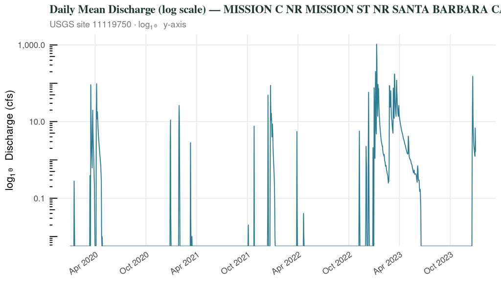

```r
ggplot(df, aes(x = Date, y = Flow)) +
  geom_line(color = "#2e7d94", linewidth = 0.5) +
  scale_x_date(date_labels = "%b %Y", date_breaks = "6 months") +
  scale_y_log10(labels = comma) +
  annotation_logticks(sides = "l") +
  labs(
    title    = paste("Daily Mean Discharge (log scale) \u2014", site_name),
    subtitle = paste("USGS site", site_no, "\u00b7 log\u2081\u2080 y-axis"),
    x        = NULL,
    y        = "log\u2081\u2080 Discharge (cfs)"
  ) +
  theme_minimal(base_size = 12) +
  theme(
    plot.title    = element_text(family = "serif", face = "bold",
                                 color = "#1e3a2f", size = 13),
    plot.subtitle = element_text(color = "#7a7a72", size = 10),
    axis.text.x   = element_text(angle = 35, hjust = 1),
    panel.grid.minor = element_blank()
  )
```

**📌 When to use log scale.** Use linear scale when you want to show the magnitude of peaks (flood hazard, infrastructure design). Use log scale when you want to see low-flow variability (drought, ecological base flow, groundwater connectivity). For most stream analysis, showing both is standard.

### 6.3 Monthly discharge boxplots

Grouping by calendar month and pooling all years reveals the **seasonal pattern** of discharge, independent of year-to-year variability. Each box shows the interquartile range, the line is the median, and points beyond the whiskers are outliers.

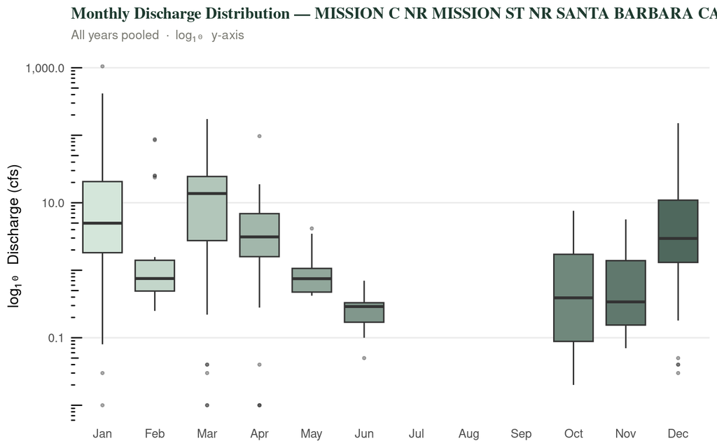

```r
ggplot(df, aes(x = month, y = Flow, fill = month)) +
  geom_boxplot(
    outlier.size  = 0.9,
    outlier.alpha = 0.4,
    show.legend   = FALSE
  ) +
  scale_y_log10(labels = comma) +
  annotation_logticks(sides = "l") +
  scale_fill_manual(
    values = colorRampPalette(c("#d4e6da", "#1e3a2f"))(12)
  ) +
  labs(
    title    = paste("Monthly Discharge Distribution \u2014", site_name),
    subtitle = "All years pooled  \u00b7  log\u2081\u2080 y-axis",
    x        = NULL,
    y        = "log\u2081\u2080 Discharge (cfs)"
  ) +
  theme_minimal(base_size = 12) +
  theme(
    plot.title    = element_text(family = "serif", face = "bold",
                                 color = "#1e3a2f", size = 13),
    plot.subtitle = element_text(color = "#7a7a72", size = 10),
    panel.grid.major.x = element_blank(),
    panel.grid.minor   = element_blank()
  )
```

## 7. Flow Duration Curve

The **flow duration curve (FDC)** is one of the most widely used tools in hydrology. It answers: *“What discharge is equalled or exceeded X% of the time?”* The curve is constructed by ranking all daily values from highest to lowest and computing each value’s exceedance probability.

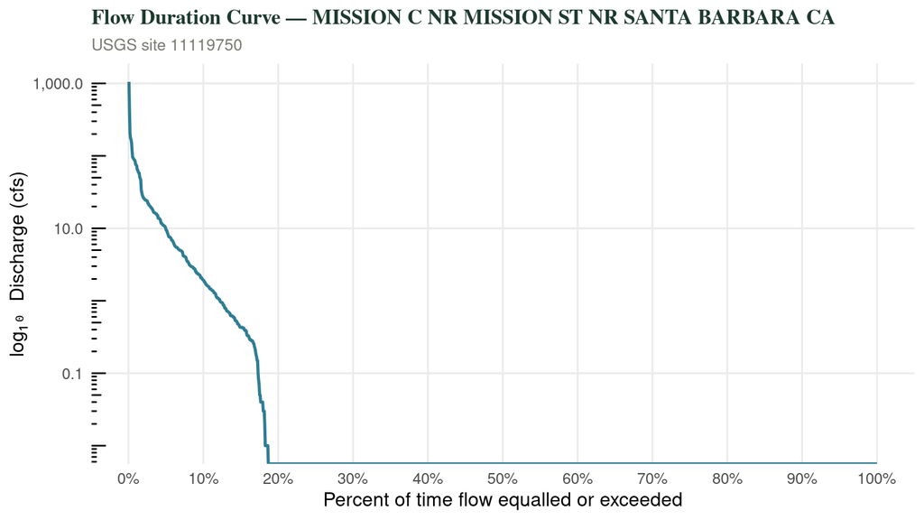

```r
fdc <- df %>%
  arrange(desc(Flow)) %>%
  mutate(exceed_pct = 100 * row_number() / n())

ggplot(fdc, aes(x = exceed_pct, y = Flow)) +
  geom_line(color = "#2e7d94", linewidth = 0.9) +
  scale_y_log10(labels = comma) +
  annotation_logticks(sides = "l") +
  scale_x_continuous(
    breaks = seq(0, 100, 10),
    labels = paste0(seq(0, 100, 10), "%")
  ) +
  labs(
    title    = paste("Flow Duration Curve \u2014", site_name),
    subtitle = paste("USGS site", site_no),
    x        = "Percent of time flow equalled or exceeded",
    y        = "log\u2081\u2080 Discharge (cfs)"
  ) +
  theme_minimal(base_size = 12) +
  theme(
    plot.title    = element_text(family = "serif", face = "bold",
                                 color = "#1e3a2f", size = 13),
    plot.subtitle = element_text(color = "#7a7a72", size = 10),
    panel.grid.minor = element_blank()
  )
```

**📌 Reading the flow duration curve.**

- **Steep FDC** — the curve drops sharply from high to low discharge over a narrow range of exceedance percentages. This indicates a *flashy*, rainfall-dominated stream: very high peak flows but very low base flows. Most Southern California streams look like this.
- **Flat FDC** — discharge changes slowly across the full range of exceedance probabilities. This indicates a *groundwater-sustained* stream with stable year-round flow, typical of the Pacific Northwest or the Appalachians.
- **The Q90 value** — the discharge exceeded 90% of the time — is a common index of ecological base flow and drought severity. The Q10 value is often used as a flood reference flow.

```r
# Extract key exceedance quantiles
q_vals <- quantile(df$Flow, probs = c(0.90, 0.50, 0.10),
                   na.rm = TRUE)
cat(sprintf("Q90 (exceeded 90%% of days): %7.1f cfs\n", q_vals["10%"]))
```

```
## Q90 (exceeded 90% of days):     0.0 cfs
```

```r
cat(sprintf("Q50 / median discharge:     %7.1f cfs\n", q_vals["50%"]))
```

```
## Q50 / median discharge:         0.0 cfs
```

```r
cat(sprintf("Q10 (exceeded 10%% of days): %7.1f cfs\n", q_vals["90%"]))
```

```
## Q10 (exceeded 10% of days):     1.9 cfs
```

```r
cat(sprintf("Flashiness ratio (Q10/Q90): %7.1f\n",
            q_vals["90%"] / q_vals["10%"]))
```

```
## Flashiness ratio (Q10/Q90):     Inf
```

**⚙️ The flashiness ratio.** Q10 / Q90 is a simple index of stream flashiness — the ratio of a high-flow reference to a low-flow reference. A ratio of 2 indicates modest variability (stable, groundwater-fed stream). A ratio of 100 or more indicates extreme flashiness (ephemeral or intermittent stream). Mediterranean-climate streams in Southern California commonly exceed 1,000.

## 8. Assignment: Analyse a Station of Your Choice

### Step 2 — Find a USGS station

**Option A — USGS WaterWatch map:** Go to waterwatch.usgs.gov, zoom to your state, click a gauge dot, and note the 8-digit site number from the popup.

**Option B — browse stations in R:**

```r
# Run this in the Console to browse sites in any state.
# Replace "CA" with your two-letter state abbreviation.
my_sites <- whatNWISsites(
  stateCd     = "CA",
  parameterCd = "00060",
  service     = "dv"
)
View(my_sites)   # opens a spreadsheet-style viewer in RStudio
```

Choose a site with:

- **Parameter 00060** (discharge) — not just stage height
- **At least 2 complete calendar years** of approved (`A`) daily records
- **No major gaps** — check the period of record shown in the popup

### Step 3 — Update the Settings chunk

Return to Section 2 and replace the three values in the settings chunk:

```r
site_no  <- "YOUR_8_DIGIT_SITE_NUMBER"
start_dt <- "YYYY-MM-DD"
end_dt   <- "YYYY-MM-DD"
```

Re-knit. All titles, labels, and the metadata line update automatically.

## Summary

#### 💡 Key takeaways

- **`readNWISdv()`** gives you programmatic access to the entire USGS daily discharge archive. The eight-digit site number is all you need to pull any station’s record.
- **Always inspect NAs after download.** Equipment failures, rating-curve extrapolations, and provisional records all produce NAs in NWIS data. Document how many you removed and why.
- **Log scale is standard for discharge.** The orders-of-magnitude range between base flow and flood peaks makes linear scale compress the low-flow period almost to invisibility.
- **The flow duration curve is the most information-dense single plot in hydrology.** One curve encodes the full statistical distribution of daily discharge — base flow, seasonal variability, and flood frequency — in a single panel.
- **Mediterranean-climate streams are inherently flashy.** The combination of seasonal rainfall concentrated in 3–4 winter months, steep terrain, and low-permeability soils produces Q10/Q90 ratios that are orders of magnitude larger than humid-continental or Pacific Northwest streams.

## References

Hirsch, R. M., and De Cicco, L. A. 2015. *User Guide to Exploration and Graphics for RivEr Trends (EGRET) and dataRetrieval*. USGS Techniques and Methods book 4, chapter A10.

USGS. 2019. *National Water Information System: Web Interface*. U.S. Geological Survey. https://waterdata.usgs.gov/nwis

EA030 RTricks | Prof. Marc Los Huertos | Pomona College | Activity 10 | Back to index